# **Aplicación Taller de Pandas**

# *DIPLOMADO DE INTELIGFENCIA ARTIFICIAL*

#### Alumno :

- **Juan David Marín Arévalo**, quimicojuanda@gmail.com

```python
# Importar librerias
import numpy as np
import pandas as pd
import seaborn as sb
import matplotlib.pyplot as plt
```

```python
# Importar el data set
db = pd.read_csv('PRSA_data_2010.1.1-2014.12.31.csv')
db.head(5)
```

|  | No | year | month | day | hour | pm2.5 | DEWP | TEMP | PRES | cbwd | Iws | Is | Ir |
| --- | --- | --- | --- | --- | --- | --- | --- | --- | --- | --- | --- | --- | --- |
| 0 | 1 | 2010 | 1 | 1 | 0 | NaN | -21 | -11.0 | 1021.0 | NW | 1.79 | 0 | 0 |
| 1 | 2 | 2010 | 1 | 1 | 1 | NaN | -21 | -12.0 | 1020.0 | NW | 4.92 | 0 | 0 |
| 2 | 3 | 2010 | 1 | 1 | 2 | NaN | -21 | -11.0 | 1019.0 | NW | 6.71 | 0 | 0 |
| 3 | 4 | 2010 | 1 | 1 | 3 | NaN | -21 | -14.0 | 1019.0 | NW | 9.84 | 0 | 0 |
| 4 | 5 | 2010 | 1 | 1 | 4 | NaN | -20 | -12.0 | 1018.0 | NW | 12.97 | 0 | 0 |

## **1. Diga qué índices serían pertienentes tener y pongalos.**

```python
dbyear = pd.read_csv('PRSA_data_2010.1.1-2014.12.31.csv', index_col=[1,2])
display(dbyear)
```

| year | month | No | day | hour | pm2.5 | DEWP | TEMP | PRES | cbwd | Iws | Is | Ir |
| --- | --- | --- | --- | --- | --- | --- | --- | --- | --- | --- | --- | --- |
| 2010 | 1 | 1 | 1 | 0 | NaN | -21 | -11.0 | 1021.0 | NW | 1.79 | 0 | 0 |
|  | 1 | 2 | 1 | 1 | NaN | -21 | -12.0 | 1020.0 | NW | 4.92 | 0 | 0 |
|  | 1 | 3 | 1 | 2 | NaN | -21 | -11.0 | 1019.0 | NW | 6.71 | 0 | 0 |
|  | 1 | 4 | 1 | 3 | NaN | -21 | -14.0 | 1019.0 | NW | 9.84 | 0 | 0 |
|  | 1 | 5 | 1 | 4 | NaN | -20 | -12.0 | 1018.0 | NW | 12.97 | 0 | 0 |
| ... | ... | ... | ... | ... | ... | ... | ... | ... | ... | ... | ... | ... |
| 2014 | 12 | 43820 | 31 | 19 | 8.0 | -23 | -2.0 | 1034.0 | NW | 231.97 | 0 | 0 |
|  | 12 | 43821 | 31 | 20 | 10.0 | -22 | -3.0 | 1034.0 | NW | 237.78 | 0 | 0 |
|  | 12 | 43822 | 31 | 21 | 10.0 | -22 | -3.0 | 1034.0 | NW | 242.70 | 0 | 0 |
|  | 12 | 43823 | 31 | 22 | 8.0 | -22 | -4.0 | 1034.0 | NW | 246.72 | 0 | 0 |
|  | 12 | 43824 | 31 | 23 | 12.0 | -21 | -3.0 | 1034.0 | NW | 249.85 | 0 | 0 |

43824 rows × 11 columns

```python
dbmonth = pd.read_csv('PRSA_data_2010.1.1-2014.12.31.csv', index_col=[2,3])
display(dbmonth)
```

| month | day | No | year | hour | pm2.5 | DEWP | TEMP | PRES | cbwd | Iws | Is | Ir |
| --- | --- | --- | --- | --- | --- | --- | --- | --- | --- | --- | --- | --- |
| 1 | 1 | 1 | 2010 | 0 | NaN | -21 | -11.0 | 1021.0 | NW | 1.79 | 0 | 0 |
|  | 1 | 2 | 2010 | 1 | NaN | -21 | -12.0 | 1020.0 | NW | 4.92 | 0 | 0 |
|  | 1 | 3 | 2010 | 2 | NaN | -21 | -11.0 | 1019.0 | NW | 6.71 | 0 | 0 |
|  | 1 | 4 | 2010 | 3 | NaN | -21 | -14.0 | 1019.0 | NW | 9.84 | 0 | 0 |
|  | 1 | 5 | 2010 | 4 | NaN | -20 | -12.0 | 1018.0 | NW | 12.97 | 0 | 0 |
| ... | ... | ... | ... | ... | ... | ... | ... | ... | ... | ... | ... | ... |
| 12 | 31 | 43820 | 2014 | 19 | 8.0 | -23 | -2.0 | 1034.0 | NW | 231.97 | 0 | 0 |
|  | 31 | 43821 | 2014 | 20 | 10.0 | -22 | -3.0 | 1034.0 | NW | 237.78 | 0 | 0 |
|  | 31 | 43822 | 2014 | 21 | 10.0 | -22 | -3.0 | 1034.0 | NW | 242.70 | 0 | 0 |
|  | 31 | 43823 | 2014 | 22 | 8.0 | -22 | -4.0 | 1034.0 | NW | 246.72 | 0 | 0 |
|  | 31 | 43824 | 2014 | 23 | 12.0 | -21 | -3.0 | 1034.0 | NW | 249.85 | 0 | 0 |

43824 rows × 11 columns

```python
dbday = pd.read_csv('PRSA_data_2010.1.1-2014.12.31.csv', index_col=[3,4])
display(dbday)
```

| day | hour | No | year | month | pm2.5 | DEWP | TEMP | PRES | cbwd | Iws | Is | Ir |
| --- | --- | --- | --- | --- | --- | --- | --- | --- | --- | --- | --- | --- |
| 1 | 0 | 1 | 2010 | 1 | NaN | -21 | -11.0 | 1021.0 | NW | 1.79 | 0 | 0 |
|  | 1 | 2 | 2010 | 1 | NaN | -21 | -12.0 | 1020.0 | NW | 4.92 | 0 | 0 |
|  | 2 | 3 | 2010 | 1 | NaN | -21 | -11.0 | 1019.0 | NW | 6.71 | 0 | 0 |
|  | 3 | 4 | 2010 | 1 | NaN | -21 | -14.0 | 1019.0 | NW | 9.84 | 0 | 0 |
|  | 4 | 5 | 2010 | 1 | NaN | -20 | -12.0 | 1018.0 | NW | 12.97 | 0 | 0 |
| ... | ... | ... | ... | ... | ... | ... | ... | ... | ... | ... | ... | ... |
| 31 | 19 | 43820 | 2014 | 12 | 8.0 | -23 | -2.0 | 1034.0 | NW | 231.97 | 0 | 0 |
|  | 20 | 43821 | 2014 | 12 | 10.0 | -22 | -3.0 | 1034.0 | NW | 237.78 | 0 | 0 |
|  | 21 | 43822 | 2014 | 12 | 10.0 | -22 | -3.0 | 1034.0 | NW | 242.70 | 0 | 0 |
|  | 22 | 43823 | 2014 | 12 | 8.0 | -22 | -4.0 | 1034.0 | NW | 246.72 | 0 | 0 |
|  | 23 | 43824 | 2014 | 12 | 12.0 | -21 | -3.0 | 1034.0 | NW | 249.85 | 0 | 0 |

43824 rows × 11 columns

Los indices que que creo son pertinentes usar son las variables **$year$**, **$month$** y **$day$**, ya que estas variables poseen valores que se repiten en las filas

## **2. Elimine registros que tengan NA en la columna "pm2.5"**

```python
no_na = db[db['pm2.5'].notna()]
print(no_na.shape)
print(db.shape)
print('La variable pm2.4 contine',db.shape[0]-no_na.shape[0],'alores NA')
```

```
(41757, 13)
(43824, 13)
La variable pm2.4 contine 2067 alores NA
```

```python
# Antes de eliminar del conjunto de datos original los valores NA de la variable pm2.5, verificamos cuantos registros hay
print(db['pm2.5'].shape)
```

```
(43824,)
```

```python
db.dropna(subset=['pm2.5'], axis = 0, inplace=True)
print(db['pm2.5'].shape)
```

```
(41757,)
```

```python
print('Se eliminaron',43824-41757,'Registros NA' )
```

```
Se eliminaron 2067 Registros NA
```

```python
print('El nuevo conjunto de datos ahora tiene', db.shape[0],'Filas y', db.shape[1],'columnas')
```

```
El nuevo conjunto de datos ahora tiene 41757 Filas y 13 columnas
```

## **3. Realice un describe de todas las variables por año. Además de realizar un gráfico como boxplot con el que pueda comparar los resultados dados.**

```python
# Descripción de las variables por año
db.groupby('year')[['month','day','hour','pm2.5','DEWP','TEMP','PRES','cbwd','Iws','Is','Ir']].sum()
```

| year | month | day | hour | pm2.5 | DEWP | TEMP | PRES | Iws | Is | Ir |
| --- | --- | --- | --- | --- | --- | --- | --- | --- | --- | --- |
| 2010 | 52549 | 126144 | 92994 | 841834.0 | 10940 | 91540.0 | 8222813.5 | 236377.43 | 624 | 2179 |
| 2011 | 53020 | 128244 | 92447 | 795741.0 | 16330 | 99660.0 | 8172252.0 | 204751.04 | 453 | 1199 |
| 2012 | 53521 | 128334 | 95443 | 751078.0 | 16206 | 100452.0 | 8428386.0 | 204142.61 | 631 | 2206 |
| 2013 | 56559 | 136023 | 99776 | 882660.0 | 11651 | 107465.0 | 8815260.5 | 182742.86 | 306 | 1405 |
| 2014 | 56346 | 136235 | 99642 | 846479.0 | 17955 | 118735.0 | 8804894.0 | 168589.83 | 297 | 1148 |

```
numpy.ndarray
```

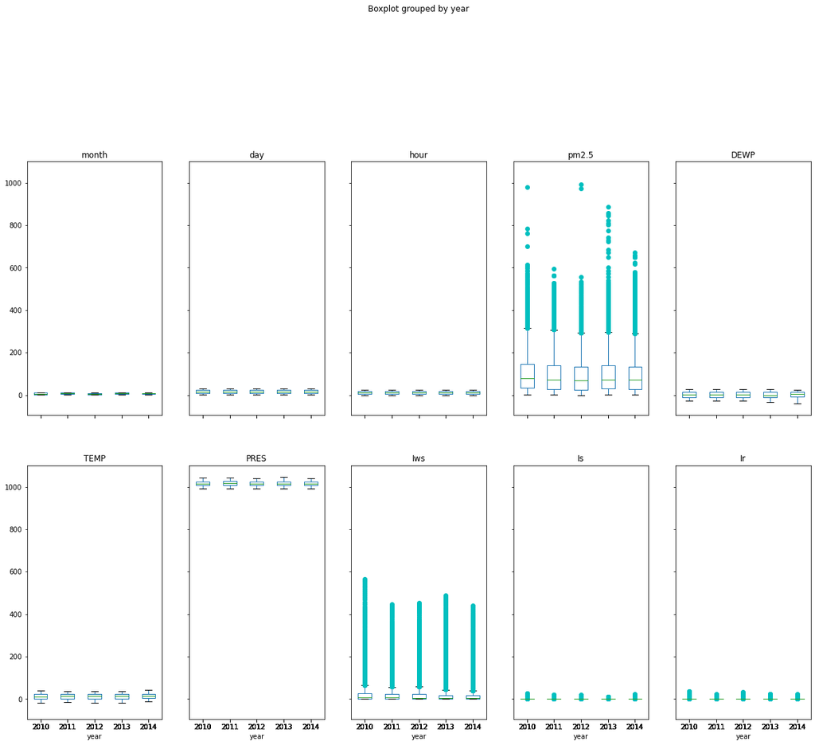

```python
# Grafico boxplot
boxplot = db.boxplot(column=['month','day','hour','pm2.5','DEWP','TEMP','PRES','Iws','Is','Ir'], by = 'year', grid=False, layout=(5,5), figsize=(20,40), sym = 'co')
type(boxplot)
```

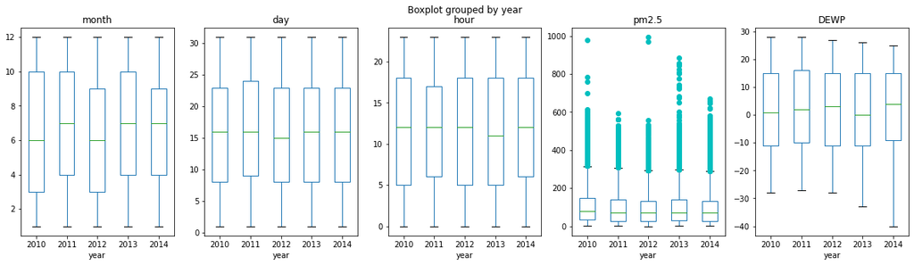

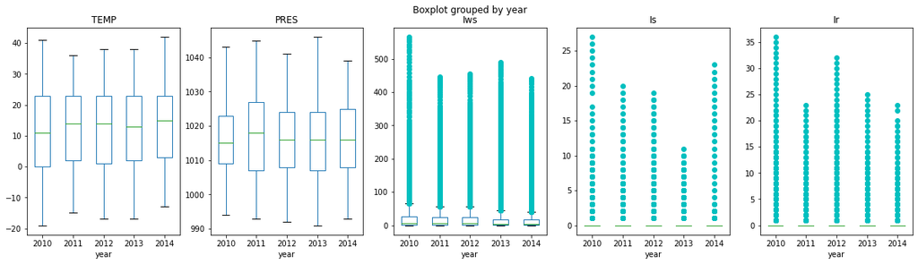

```python
fig, ax = plt.subplots(1,5, figsize=(20, 5))
db.boxplot('month','year', ax=ax[0],grid=False,sym = 'co')
db.boxplot('day','year', ax=ax[1],grid=False,sym = 'co')
db.boxplot('hour','year', ax=ax[2],grid=False,sym = 'co')
db.boxplot('pm2.5','year', ax=ax[3],grid=False,sym = 'co')
db.boxplot('DEWP','year', ax=ax[4],grid=False,sym = 'co')

fig, ax = plt.subplots(1,5, figsize=(20, 5))
db.boxplot('TEMP','year', ax=ax[0],grid=False,sym = 'co')
db.boxplot('PRES','year', ax=ax[1],grid=False,sym = 'co')
db.boxplot('Iws','year', ax=ax[2],grid=False,sym = 'co')
db.boxplot('Is','year', ax=ax[3],grid=False,sym = 'co')
db.boxplot('Ir','year', ax=ax[4],grid=False,sym = 'co')
```

## **4. Realice un gráfico de disperción de las variables "pm2.5" y "TEMP" con título, labels apropiados y color rojo para los datos. Describa: ¿Qué se puede inferir de dicho gráfico?**

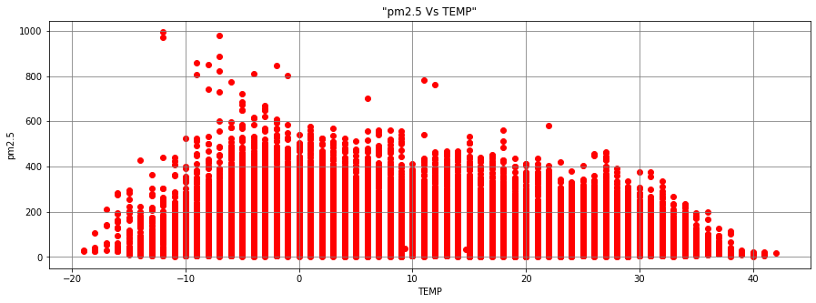

```python
fig, ax = plt.subplots(figsize=(15,5))
x = db['TEMP']
y = db['pm2.5']
plt.scatter(x,y, c = 'red')
plt.title('"pm2.5 Vs TEMP"')
plt.ylabel('pm2.5')
plt.xlabel('TEMP')
plt.grid(c = 'gray')
```

Cuando la temperatura es baja, entre $-10°c$ y $10°c$, es más probable que haya valores altos de $pm2.5$, por lo tanto, se encontraran días altamente contaminados

## **5. Calcule la probabilidad de encontrar en la Base de datos el valor de pm2.5 encima de 120**

```python
# total de registros para la variable pm2.5
print('La variable pm2.5 tiene',db['pm2.5'].shape[0],'registros en total y','\n',
      db[db['pm2.5']>120].shape[0],'registros por encima de 120')

print('La probabilidad de encontrar valores de concentración por encima de 120 para la variable pm2.5 es de','\n',
 ((db[db['pm2.5']>120].shape[0])/(db['pm2.5'].shape[0]))*100,'%')
```

[output not shown]

## **6. Agrupe por año el valor de la variable "pm2.5", calcule el promedio y ordene la base de datos de manera ascendente por el promedio.**

```python
db_sort = (db.groupby('year')[['pm2.5']]
          .mean()
          .sort_values('pm2.5', ascending = True))
display(db_sort)
```

| year | pm2.5 |
| --- | --- |
| 2012 | 90.545871 |
| 2014 | 97.734557 |
| 2011 | 99.071340 |
| 2013 | 101.712376 |
| 2010 | 104.045730 |